# Przewidywanie energii wytrwarzanej przez panele fotowoltaiczne

Bartosz Wysocki

05 grudzień 2017

## Spis treści

1. Wstęp
2. Wykorzystane biblioteki
3. Przygotowanie danych
4. Zbiór danych
5. Korelacja między zmiennymi
6. Animacja pokazująca różnicę w wytwarzanej energii w 2012 i 2013 roku
7. Regresor przewidujący wytwarzaną energię
8. Analiza ważności atrybutów najlepszego modelu regresji

## Wstęp

Raport został stworzony w celu analizy danych z czujników paneli fotowoltaicznych, co doprowadziło do określenia jakie czynniki najlepiej pozwalają przewidzieć energię wytwarzaną w przyszłości. Największą trudność stanowiło uzupełnienie błędnych wartości pomiarów czujników. Aby tworzenie modelu regresji przebiegło pomyślnie należało jak najlepiej uzupełnić nieprawidłowe dane związane z nasłonecznieniem i wytwarzaną energią, bo to własnie nasłonecznienie najbardziej wpływa na wartość wytworzonej energii.

Aby zapewnić powtarzalność wyników przy każdym generowaniu raportu należało wykonać poniższy fragment kodu:

```r
set.seed(23)
```

## Wykorzystane biblioteki

```r
library(knitr)        # generowanie raportu
library(dplyr)        # przetwarzanie danych jak w SQL
library(lubridate)    # ułatwienie pracy z datami
library(reshape2)     # udostępnia funkcje melt i cast do przetwarzania danych
library(corrplot)     # wizualizacja korelacji między zmiennymi
library(ggplot2)      # tworzenie wykresów
library(gganimate)    # tworzenie animacji na wykresach
library(directlabels) # dodanie etykiet do linii na wykresach
library(caret)        # klasyfikacja i regresja
```

## Przygotowanie danych

### Wczytanie danych

```r
sciezka_do_pliku = paste(getwd(), "elektrownie.csv", sep = "/") # wczytanie ścieżki do pliku z danymi
dane <- read.csv(file = sciezka_do_pliku, row.names=1)          # wczytanie zbioru danych
dane$data <- as.POSIXct(strptime(dane$data, "%m/%d/%Y %k:%M"))  # konwersja daty do odpowiedniego formatu
```

### Nadpisywanie błędnych wartości

Przy wstępnej analizie danych największą uwagę skupiają wartości godziny, nasłonecznienia, zachmurzenia oraz wytwarzanej energii. Nie trzeba być ekspertem w dziedzinie elektrowni słonecznych, aby mieć świadomość, że są to wartości kluczowe. Badając wartości skrajne można zauważyć pewne nieścisłości, np. dodatnie wartości wytwarzanej energii przy zerowym nasłonecznieniu, czy zerowa wartości wytwarzanej energii przy dodatnim nasłonecznieniu.

W celu korekty danych wykonano następujące czynności:

```r
# dodanie kolumny month, aby ułatwić dalsze operacje
dane <- dane %>% mutate(month = month(data))
# nadpisanie zerowej wartości kwh średnią z tej samej godziny w danym miesiącu, jeżeli nasłonecznienie > 0
dane <- dane %>% group_by(idsito, anno, month, ora) %>% mutate(kwh = ifelse(kwh == 0 & irradiamento > 0, mean(kwh), kwh))
# nadpisanie zerowej wartości nasłonecznienia średnią z tego miesiąca w danym roku, jeżeli kwh > 0
dane <- dane %>% group_by(idsito, anno, month) %>% mutate(irradiamento = ifelse(irradiamento == 0 & kwh > 0, mean(irradiamento), irradiamento))
```

Korekta w odniesieniu do zachmurzenia lub godziny wymagałaby znacznie bardziej skomplikowanej analizy poprzez np. uwzględnienie pór roku.

## Zbiór danych

### Podstawowe statystyki

- Liczba wierszy: 235790
- Liczba kolumn: 51
- Liczba paneli fotowoltaicznych: 17

### Codebook - opis zmiennych

Większość zmiennych jest znormalizowanych do wartości <0, 1>

1. Dane pomiaru:  
   id - identyfikator anno - rok (2012, 2013)  
   day - dzień roku (1-365)  
   ora - godzina (2:00-20:00)  
   data - data  
   kwh - ilość wytworzonej energii
2. Dane panelu: id_sito - identyfikator  
   id_model - identyfikator modelu  
   id_brand - identyfikator marki  
   lat - długość geograficzna  
   lon - szerokość geograficzna  
   ageinmonths - wiek w miesiącach  
   azimuth - azymut  
   altitude - wysokość bezwzględna
3. Dane pogodowe:  
   temperatura_ambiente - temperatura powietrza  
   irradiamento - nasłonecznienie  
   pressure - ciśnienie  
   windspeed - prędkość wiatru  
   humidity - wilgotność  
   dewpoint - temperatura punktu rosy  
   windbearing - kierunek wiatru  
   cloudcover - zachmurzenie
4. Dane LISA: podobne do danych pogodowych lokalne statystyki obliczane za pomocą algorytmu LISA przy użyciu PCNM
5. Dane PCNM: 1-15 - argumenty algorytmu analizy współrzędnych głównych macierzy sąsiedztwa

### Przykładowe dane

| idsito | idmodel | idbrand | lat | lon | ageinmonths | anno | day | ora | data | temperatura_ambiente | irradiamento | pressure | windspeed | humidity | icon | dewpoint | windbearing | cloudcover | tempi | irri | pressurei | windspeedi | humidityi | dewpointi | windbearingi | cloudcoveri | dist | altitude | azimuth | … |
| --- | --- | --- | --- | --- | --- | --- | --- | --- | --- | --- | --- | --- | --- | --- | --- | --- | --- | --- | --- | --- | --- | --- | --- | --- | --- | --- | --- | --- | --- | --- |
| 0.250 | 0.208 | 0.083 | 0.437 | 0.620 | 0.063 | 2013 | 0.151 | 0.944 | 2013-02-25 19:00:00 | 0.318 | 0.000 | 0.754 | 0.029 | 0.75 | 0.083 | 0.482 | 0.630 | 0.06 | 0.075 | 0.222 | 0 | 0.038 | 0.044 | 0.128 | 0.337 | 0.197 | 0.7213115 | 0.545 | 0.719 | … |
| 0.100 | 0.167 | 0.167 | 0.434 | 0.630 | 0.000 | 2012 | 0.447 | 0.889 | 2012-06-12 18:00:00 | 0.576 | 0.002 | 0.747 | 0.088 | 0.61 | 0.000 | 0.722 | 0.375 | 0.03 | 0.289 | 0.221 | 0 | 0.038 | 0.045 | 0.114 | 0.336 | 0.197 | 0.1311475 | 0.702 | 0.763 | … |
| 0.125 | 0.167 | 0.167 | 0.415 | 0.691 | 0.000 | 2012 | 0.644 | 0.556 | 2012-08-23 12:00:00 | 0.697 | 0.319 | 0.754 | 0.025 | 0.26 | 0.000 | 0.648 | 0.435 | 0.00 | 0.072 | 0.216 | 0 | 0.037 | 0.044 | 0.114 | 0.336 | 0.196 | 0.2622951 | 0.754 | 0.423 | … |
| 0.000 | 0.000 | 0.333 | 0.436 | 0.626 | 0.719 | 2013 | 0.422 | 0.833 | 2013-06-03 17:00:00 | 0.485 | 0.014 | 0.752 | 0.057 | 0.77 | 0.667 | 0.653 | 0.266 | 0.31 | 0.130 | 0.220 | 0 | 0.038 | 0.052 | 0.114 | 0.362 | 0.190 | 0.1803279 | 0.757 | 0.735 | … |
| 0.050 | 0.125 | 0.417 | 0.437 | 0.622 | 0.844 | 2013 | 0.529 | 0.611 | 2013-07-12 13:00:00 | 0.652 | 0.342 | 0.754 | 0.071 | 0.73 | 0.667 | 0.749 | 0.077 | 0.31 | 0.194 | 0.229 | 0 | 0.038 | 0.044 | 0.114 | 0.341 | 0.189 | 0.0327869 | 0.845 | 0.449 | … |

### Podsumowanie wartości atrybutów

|  | idsito | idmodel | idbrand | lat | lon | ageinmonths | anno | day | ora | data | temperatura_ambiente | irradiamento | pressure | windspeed | humidity | icon | dewpoint | windbearing | cloudcover | tempi | irri | pressurei | windspeedi | humidityi | dewpointi | windbearingi | cloudcoveri | dist | altitude | … |
| --- | --- | --- | --- | --- | --- | --- | --- | --- | --- | --- | --- | --- | --- | --- | --- | --- | --- | --- | --- | --- | --- | --- | --- | --- | --- | --- | --- | --- | --- | --- |
|  | Min. :0.0000 | Min. :0.0000 | Min. :0.0000 | Min. :0.4150 | Min. :0.1540 | Min. :0.0000 | Min. :2012 | Min. :0.0000 | Min. :0.000 | Min. :2012-01-02 02:00:00 | Min. :0.0450 | Min. :0.0000 | Min. :0.0000 | Min. :0.00000 | Min. :0.1600 | Min. :0.0000 | Min. :0.1390 | Min. :0.0000 | Min. :0.000 | Min. :0.0090 | Min. :0.108 | Min. :0.000000 | Min. :0.00000 | Min. :0.03400 | Min. :0.0630 | Min. :0.0000 | Min. :0.0000 | Min. :0.0000 | Min. :0.1110 | … |
|  | 1st Qu.:0.1000 | 1st Qu.:0.1670 | 1st Qu.:0.0830 | 1st Qu.:0.4370 | 1st Qu.:0.6200 | 1st Qu.:0.0000 | 1st Qu.:2012 | 1st Qu.:0.2520 | 1st Qu.:0.222 | 1st Qu.:2012-07-02 11:45:00 | 1st Qu.:0.2120 | 1st Qu.:0.0000 | 1st Qu.:0.7480 | 1st Qu.:0.04200 | 1st Qu.:0.5400 | 1st Qu.:0.0830 | 1st Qu.:0.5350 | 1st Qu.:0.3000 | 1st Qu.:0.230 | 1st Qu.:0.0730 | 1st Qu.:0.216 | 1st Qu.:0.000000 | 1st Qu.:0.03700 | 1st Qu.:0.04400 | 1st Qu.:0.1140 | 1st Qu.:0.3360 | 1st Qu.:0.1960 | 1st Qu.:0.1913 | 1st Qu.:0.4190 | … |
|  | Median :0.2250 | Median :0.2080 | Median :0.1670 | Median :0.4370 | Median :0.6240 | Median :0.1250 | Median :2012 | Median :0.4770 | Median :0.500 | Median :2012-12-31 23:00:00 | Median :0.3480 | Median :0.0380 | Median :0.7530 | Median :0.06600 | Median :0.7000 | Median :0.6670 | Median :0.6190 | Median :0.4780 | Median :0.310 | Median :0.1110 | Median :0.220 | Median :0.000000 | Median :0.03800 | Median :0.04400 | Median :0.1140 | Median :0.3360 | Median :0.1960 | Median :0.4590 | Median :0.5640 | … |
|  | Mean :0.2147 | Mean :0.2426 | Mean :0.1519 | Mean :0.4495 | Mean :0.5711 | Mean :0.3145 | Mean :2012 | Mean :0.4812 | Mean :0.500 | Mean :2012-12-31 22:44:54 | Mean :0.3734 | Mean :0.1099 | Mean :0.6504 | Mean :0.07622 | Mean :0.6844 | Mean :0.4623 | Mean :0.6055 | Mean :0.4512 | Mean :0.359 | Mean :0.1225 | Mean :0.222 | Mean :0.000237 | Mean :0.03852 | Mean :0.06384 | Mean :0.1194 | Mean :0.3455 | Mean :0.2062 | Mean :0.4686 | Mean :0.5464 | … |
|  | 3rd Qu.:0.3250 | 3rd Qu.:0.2920 | 3rd Qu.:0.1670 | 3rd Qu.:0.4390 | 3rd Qu.:0.6300 | 3rd Qu.:0.7190 | 3rd Qu.:2013 | 3rd Qu.:0.7100 | 3rd Qu.:0.778 | 3rd Qu.:2013-07-02 11:15:00 | 3rd Qu.:0.5300 | 3rd Qu.:0.2044 | 3rd Qu.:0.7550 | 3rd Qu.:0.10200 | 3rd Qu.:0.8400 | 3rd Qu.:0.6670 | 3rd Qu.:0.6830 | 3rd Qu.:0.6600 | 3rd Qu.:0.510 | 3rd Qu.:0.1260 | 3rd Qu.:0.222 | 3rd Qu.:0.000000 | 3rd Qu.:0.03900 | 3rd Qu.:0.06200 | 3rd Qu.:0.1180 | 3rd Qu.:0.3390 | 3rd Qu.:0.1980 | 3rd Qu.:0.7268 | 3rd Qu.:0.6810 | … |
|  | Max. :0.4250 | Max. :0.7500 | Max. :0.4170 | Max. :0.5530 | Max. :0.6910 | Max. :1.0000 | Max. :2013 | Max. :1.0000 | Max. :1.000 | Max. :2013-12-31 20:00:00 | Max. :0.8180 | Max. :0.7100 | Max. :0.7690 | Max. :0.69600 | Max. :1.0000 | Max. :0.7500 | Max. :0.8650 | Max. :0.7690 | Max. :1.000 | Max. :0.9830 | Max. :1.000 | Max. :1.000000 | Max. :1.00000 | Max. :0.57900 | Max. :0.4150 | Max. :1.0000 | Max. :1.0000 | Max. :1.0000 | Max. :0.8840 | … |

## Korelacja między zmiennymi

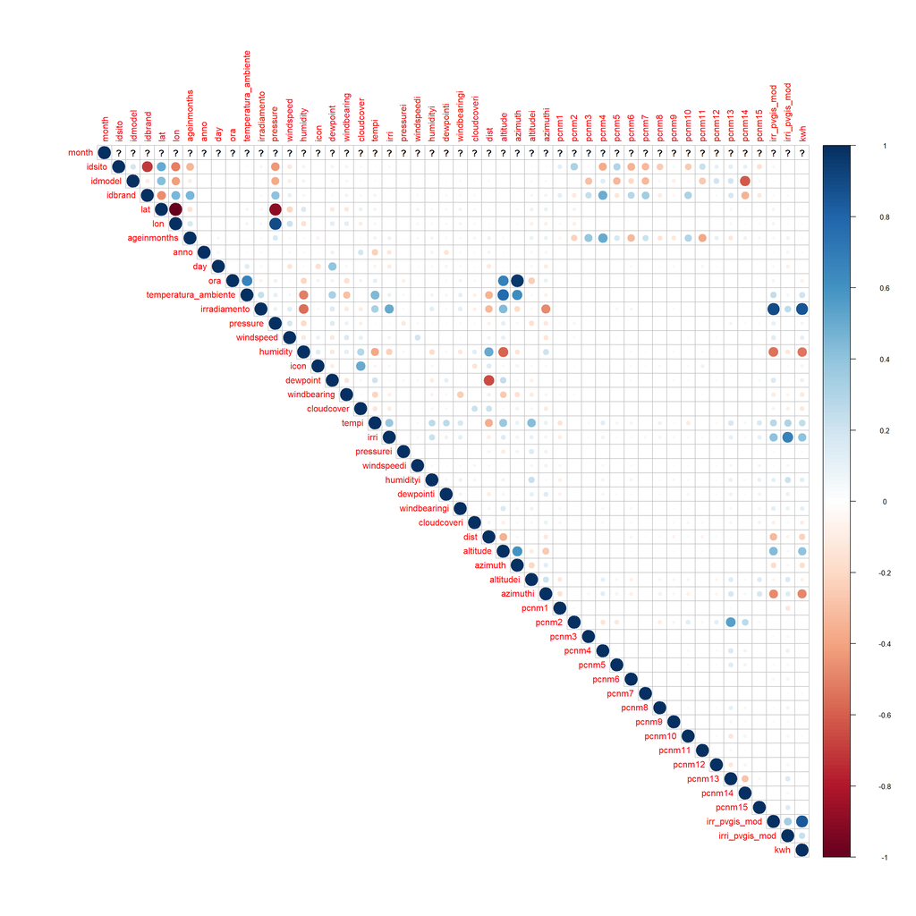

Jak można było przypuszczać wykres wykazał silną dodatnią korelację pomiędzy kwh, a irradiamento (nasłonecznienie). Co ciekawe zamiast dużej ujemnej korelacji pomiędzy kwh, a cloudcover (zachmurzenie) można zauważyć ujemną korelację pomiędzy kwh, a humidity (wilgotność).

## Animacja pokazująca różnicę w wytwarzanej energii w 2012 i 2013 roku

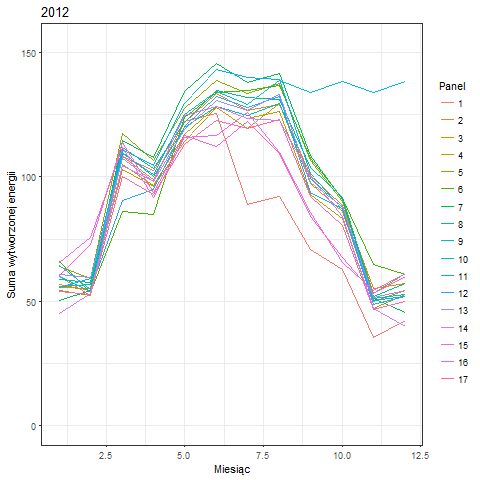

Na powyższym wykresie można zauważyć:  
1. W 2012 roku duże wartości od sierpnia na czujniku panelu 10 w porównaniu do reszty czujników  
2. W roku 2013 panel 15 prawdopodobnie uległ awarii w sierpniu (nagły spadek do zera)  
3. W roku 2013 czujniki 1, 2, 3, 4 zaczynają rok od bardzo niskich pomiarów, a 5, 6, 7, 10 znacznie odbiegają od reszty w listopadzie i grudniu.

## Regresor przewidujący wytwarzaną energię

Przed testowaniem różnych algorytmów regresji usunięto czujnik nr 10, który jako jedyny wykazywał zbyt optymistyczne wartości wytwarzanej energii. Sytuację z roku 2013 można uznać za prawdopodobną.

Wybrano następujące algorytmy:  
* Generalized Linear Model  
* Linear Regression

|  | RMSE |
| --- | --- |
| Generalized Linear Model | 0.0944286 |
| Linear Regression | 0.0944148 |

Najlepszym modelem okazał się: Linear Regression

```
## glm variable importance
##
##   only 20 most important variables shown (out of 46)
##
##                Overall
## irradiamento   120.260
## irr_pvgis_mod  102.125
## humidity        55.467
## dist            52.706
## day             35.886
## cloudcover      33.524
## altitudei       32.815
## idsito8         21.976
## irri_pvgis_mod  18.827
## altitude        18.067
## azimuthi        15.414
## dewpoint        14.868
## anno            12.577
## azimuth         11.670
## irri            11.516
## data            10.321
## cloudcoveri      9.055
## humidityi        8.185
## ora              5.509
## windbearing      4.949
```

Największą ważność miała zmienna irradiamento (nasłonecznienie).